# Statistical analysis and document mining - TP1

### Jan Zavadil, Elliott Perryman, Ignat Sabaev

## Part 1:

#### 1)

```r
set.seed(0)

rows = 6000
cols = 201

data = rnorm(rows*cols)
mat = matrix(data,nrow = rows)
df = data.frame(mat)
```

#### 2)

```r
model = summary(lm(X1 ~ . , data = df))

sum(model$coefficients[,4]<0.05)
```

```
## [1] 9
```

The number of coefficients assessed as significantly non-zero at the level of 5% is 9. The first variable is drawn completely independently of the other ones, all the coefficients should be equal to zero.

#### 4)

Next we simulate a sample of size $n = 1000$ of the following model
$$X_{1,i} = \varepsilon_{1,i} \\
X_{2,i} = 3X_{1,i} + \varepsilon_{2,i} \\
Y_{i} = X_{1,i} + X_{2,i} + 2 + \varepsilon_{3,i}.$$

```r
X1 = rnorm(1000)
X2 = 3*X1 + rnorm(1000)
Y = X1 + X2 + 2 + rnorm(1000)
dat = data.frame(X1,X2,Y)
```

The distribution of $(X_{1,i},X_{2,i})$ for a given $i$ is two dimensional normal distribution, therefore if we plot the generated samples of $(X_{1,i},X_{2,i})$ we get a cloud of points shaped as an ellipsoid. This shape is given by the form of 2-D normal density.

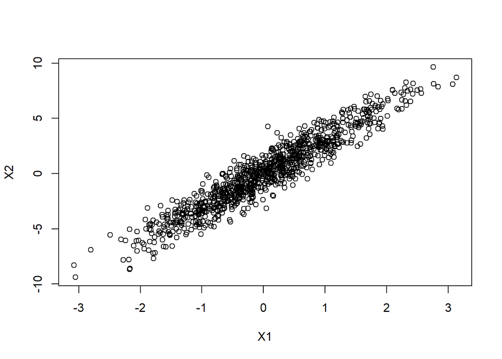

```r
plot(X1,X2)
```

#### 5)

Model 1: $Y_{i} = \beta_1 X_{1,i} + \beta_0 + \tilde{\varepsilon}_{1,i}$

```r
summary(lm(Y ~ X1,data = dat))
```

```
##
## Call:
## lm(formula = Y ~ X1, data = dat)
##
## Residuals:
##     Min      1Q  Median      3Q     Max
## -5.0203 -0.8801  0.0358  0.9690  4.4167
##
## Coefficients:
##             Estimate Std. Error t value Pr(>|t|)
## (Intercept)  2.01065    0.04371   45.99   <2e-16 ***
## X1           4.05262    0.04351   93.14   <2e-16 ***
## ---
## Signif. codes:  0 '***' 0.001 '**' 0.01 '*' 0.05 '.' 0.1 ' ' 1
##
## Residual standard error: 1.382 on 998 degrees of freedom
## Multiple R-squared:  0.8968, Adjusted R-squared:  0.8967
## F-statistic:  8676 on 1 and 998 DF,  p-value: < 2.2e-16
```

Model 2: $Y_{i} = \beta_2 X_{2,i} + \beta_0 + \tilde{\varepsilon}_{2,i}$

```r
summary(lm(Y ~ X2,data = dat))
```

```
##
## Call:
## lm(formula = Y ~ X2, data = dat)
##
## Residuals:
##     Min      1Q  Median      3Q     Max
## -4.0205 -0.7049  0.0432  0.7061  2.9802
##
## Coefficients:
##             Estimate Std. Error t value Pr(>|t|)
## (Intercept)  2.02616    0.03258   62.19   <2e-16 ***
## X2           1.29734    0.01013  128.12   <2e-16 ***
## ---
## Signif. codes:  0 '***' 0.001 '**' 0.01 '*' 0.05 '.' 0.1 ' ' 1
##
## Residual standard error: 1.03 on 998 degrees of freedom
## Multiple R-squared:  0.9427, Adjusted R-squared:  0.9426
## F-statistic: 1.642e+04 on 1 and 998 DF,  p-value: < 2.2e-16
```

Estimates of $\beta_0, \beta_1, \beta_2, \sigma^2$ are really close to their true values:
$$\beta_0 \approx 2 \\ \beta_1 \approx 4 \\ \beta_2 \approx 1.33 \\ \sigma^2 \approx 1$$
Now we estimate parameters for this model again fo $n = 10$.

```r
set.seed(3)

X1 = rnorm(10)
X2 = 3*X1 + rnorm(10)
Y = X1 + X2 + 2 + rnorm(10)
dat = data.frame(X1,X2,Y)

summary(lm(Y ~ X1,data = dat))
```

```
##
## Call:
## lm(formula = Y ~ X1, data = dat)
##
## Residuals:
##     Min      1Q  Median      3Q     Max
## -1.4216 -0.5664 -0.3675  0.6896  1.8840
##
## Coefficients:
##             Estimate Std. Error t value Pr(>|t|)
## (Intercept)   1.3733     0.3258   4.215  0.00294 **
## X1            4.0861     0.3954  10.334 6.64e-06 ***
## ---
## Signif. codes:  0 '***' 0.001 '**' 0.01 '*' 0.05 '.' 0.1 ' ' 1
##
## Residual standard error: 1.027 on 8 degrees of freedom
## Multiple R-squared:  0.9303, Adjusted R-squared:  0.9216
## F-statistic: 106.8 on 1 and 8 DF,  p-value: 6.637e-06
```

```r
summary(lm(Y ~ X2,data = dat))
```

```
##
## Call:
## lm(formula = Y ~ X2, data = dat)
##
## Residuals:
##     Min      1Q  Median      3Q     Max
## -1.3320 -0.3809 -0.0879  0.2556  1.7751
##
## Coefficients:
##             Estimate Std. Error t value Pr(>|t|)
## (Intercept)   1.7662     0.3292   5.365 0.000674 ***
## X2            1.4239     0.1370  10.397 6.34e-06 ***
## ---
## Signif. codes:  0 '***' 0.001 '**' 0.01 '*' 0.05 '.' 0.1 ' ' 1
##
## Residual standard error: 1.021 on 8 degrees of freedom
## Multiple R-squared:  0.9311, Adjusted R-squared:  0.9225
## F-statistic: 108.1 on 1 and 8 DF,  p-value: 6.344e-06
```

The only difference we see is lower precision in parameter estimation and remarkably lower values of t-tests and F-tests in both cases.

#### 6)

```r
summary(lm(Y ~ .,data = dat))
```

```
##
## Call:
## lm(formula = Y ~ ., data = dat)
##
## Residuals:
##      Min       1Q   Median       3Q      Max
## -0.99896 -0.66387 -0.09066  0.71179  1.30298
##
## Coefficients:
##             Estimate Std. Error t value Pr(>|t|)
## (Intercept)   1.5812     0.3234   4.890  0.00177 **
## X1            2.0628     1.2974   1.590  0.15588
## X2            0.7336     0.4519   1.623  0.14855
## ---
## Signif. codes:  0 '***' 0.001 '**' 0.01 '*' 0.05 '.' 0.1 ' ' 1
##
## Residual standard error: 0.9357 on 7 degrees of freedom
## Multiple R-squared:  0.9494, Adjusted R-squared:  0.9349
## F-statistic: 65.63 on 2 and 7 DF,  p-value: 2.92e-05
```

There is a high correlation between $X_1$ and $X_2$, which causes them both to be evaluated as unimportant to explain the model.

## Part 2

```r
prostateCancer<- read.table("./prostate.data", header=T)
attach(prostateCancer)
pro<- data.frame(prostateCancer)
drop <- c("train")
pro = pro[,!(names(pro) %in% drop)]
```

### 3. Best subset selection

#### a)

First model is $lcavol = \beta_0 + \varepsilon$. It is a model of size O.

```r
model = lm(lcavol ∼ 1, data=pro)
summary(model)
```

```
##
## Call:
## lm(formula = lcavol ~ 1, data = pro)
##
## Residuals:
##      Min       1Q   Median       3Q      Max
## -2.69708 -0.83719  0.09691  0.77703  2.47099
##
## Coefficients:
##             Estimate Std. Error t value Pr(>|t|)
## (Intercept)   1.3500     0.1197   11.28   <2e-16 ***
## ---
## Signif. codes:  0 '***' 0.001 '**' 0.01 '*' 0.05 '.' 0.1 ' ' 1
##
## Residual standard error: 1.179 on 96 degrees of freedom
```

```r
paste0("Residual sum of squares is ",deviance(model))
```

```
## [1] "Residual sum of squares is 133.359033889223"
```

Following model is $lcavol = \beta_1 lbph + \beta_2 lpsa + \varepsilon$. It is a model of size 2.

```r
model = lm(lcavol ∼ ., data=pro[,c(1,4,9)])
summary(model)
```

```
##
## Call:
## lm(formula = lcavol ~ ., data = pro[, c(1, 4, 9)])
##
## Residuals:
##     Min      1Q  Median      3Q     Max
## -2.2998 -0.6245  0.0414  0.5564  1.6266
##
## Coefficients:
##             Estimate Std. Error t value Pr(>|t|)
## (Intercept) -0.54900    0.19459  -2.821  0.00583 **
## lbph        -0.08791    0.05709  -1.540  0.12697
## lpsa         0.76979    0.07176  10.728  < 2e-16 ***
## ---
## Signif. codes:  0 '***' 0.001 '**' 0.01 '*' 0.05 '.' 0.1 ' ' 1
##
## Residual standard error: 0.7983 on 94 degrees of freedom
## Multiple R-squared:  0.5508, Adjusted R-squared:  0.5412
## F-statistic: 57.62 on 2 and 94 DF,  p-value: < 2.2e-16
```

```r
paste0("Residual sum of squares is ",deviance(model))
```

```
## [1] "Residual sum of squares is 59.9097892820639"
```

The last model is $lcavol = \beta_1 lweight + \beta_2 lpsa + \varepsilon$. It is a model of size 2.

```r
model = lm(lcavol ∼ ., data=pro[,c(1,2,9)])
summary(model)
```

```
##
## Call:
## lm(formula = lcavol ~ ., data = pro[, c(1, 2, 9)])
##
## Residuals:
##      Min       1Q   Median       3Q      Max
## -2.06980 -0.60231  0.05406  0.53762  1.70037
##
## Coefficients:
##             Estimate Std. Error t value Pr(>|t|)
## (Intercept) -0.09570    0.71596  -0.134    0.894
## lweight     -0.12781    0.21327  -0.599    0.550
## lpsa         0.77047    0.07915   9.734 6.75e-16 ***
## ---
## Signif. codes:  0 '***' 0.001 '**' 0.01 '*' 0.05 '.' 0.1 ' ' 1
##
## Residual standard error: 0.8068 on 94 degrees of freedom
## Multiple R-squared:  0.5412, Adjusted R-squared:  0.5314
## F-statistic: 55.44 on 2 and 94 DF,  p-value: < 2.2e-16
```

```r
paste0("Residual sum of squares is ",deviance(model))
```

```
## [1] "Residual sum of squares is 61.1871213344348"
```

The lowest residual sum of squares, as well as the highest value of F-test, is observed with the second implemented model.

#### b)

```r
comb = combn(8,2)
for (i in 1:28) {
  vect = c(1,comb[1,i]+1,comb[2,i]+1)
  print(paste(" RSS for combination - ",comb[1,i]+1 ,",",comb[2,i]+1," is ",deviance(lm(lcavol ∼ ., data=pro[,vect]))))
}
```

```
## [1] " RSS for combination -  2 , 3  is  120.402501227025"
## [1] " RSS for combination -  2 , 4  is  121.31398244673"
## [1] " RSS for combination -  2 , 5  is  89.3452701547991"
## [1] " RSS for combination -  2 , 6  is  68.6076487865289"
## [1] " RSS for combination -  2 , 7  is  99.6599372602952"
## [1] " RSS for combination -  2 , 8  is  100.895025274654"
## [1] " RSS for combination -  2 , 9  is  61.1871213344348"
## [1] " RSS for combination -  3 , 4  is  126.205507884574"
## [1] " RSS for combination -  3 , 5  is  91.1061939836275"
## [1] " RSS for combination -  3 , 6  is  69.9302061444024"
## [1] " RSS for combination -  3 , 7  is  106.723592066783"
## [1] " RSS for combination -  3 , 8  is  106.680685657678"
## [1] " RSS for combination -  3 , 9  is  60.035696734806"
## [1] " RSS for combination -  4 , 5  is  93.9098332051736"
## [1] " RSS for combination -  4 , 6  is  72.4041932988172"
## [1] " RSS for combination -  4 , 7  is  108.417632986711"
## [1] " RSS for combination -  4 , 8  is  108.274319621022"
## [1] " RSS for combination -  4 , 9  is  59.9097892820639"
## [1] " RSS for combination -  5 , 6  is  70.8091732639893"
## [1] " RSS for combination -  5 , 7  is  84.6094196046382"
## [1] " RSS for combination -  5 , 8  is  88.7355809176743"
## [1] " RSS for combination -  5 , 9  is  58.4521881833056"
## [1] " RSS for combination -  6 , 7  is  71.2382091573899"
## [1] " RSS for combination -  6 , 8  is  72.5299945406043"
## [1] " RSS for combination -  6 , 9  is  47.2780972897865"
## [1] " RSS for combination -  7 , 8  is  104.809860064083"
## [1] " RSS for combination -  7 , 9  is  57.3988304284976"
## [1] " RSS for combination -  8 , 9  is  58.946249575393"
```

The lowest RSS is reached with combination of predictors 6 and 9 (lcp, lpsa).